# XLM-USD

## XLM-USD today is +0300, 2025-10-24, 19:02:22

This crypto forecast was generated by gemini-2.0-flash API

## Daily Chart

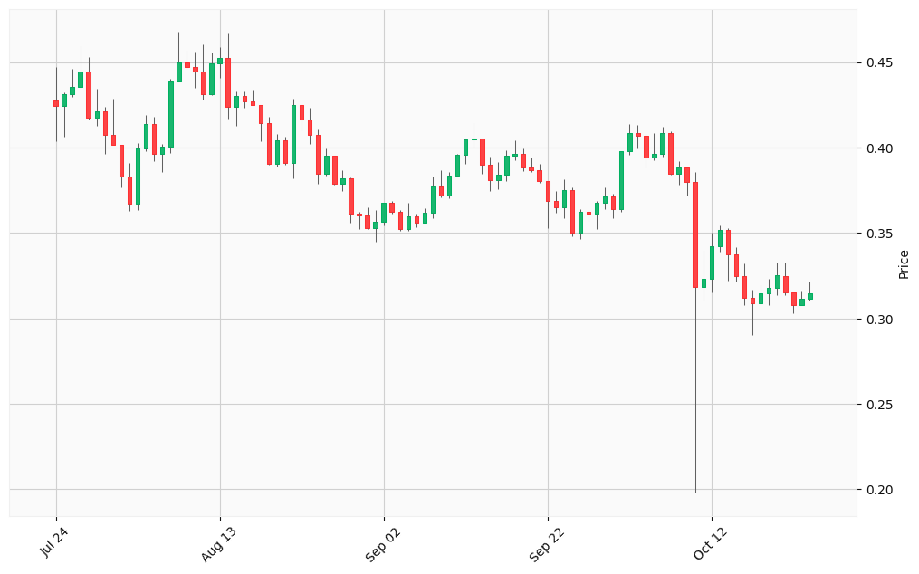

## Hourly Chart

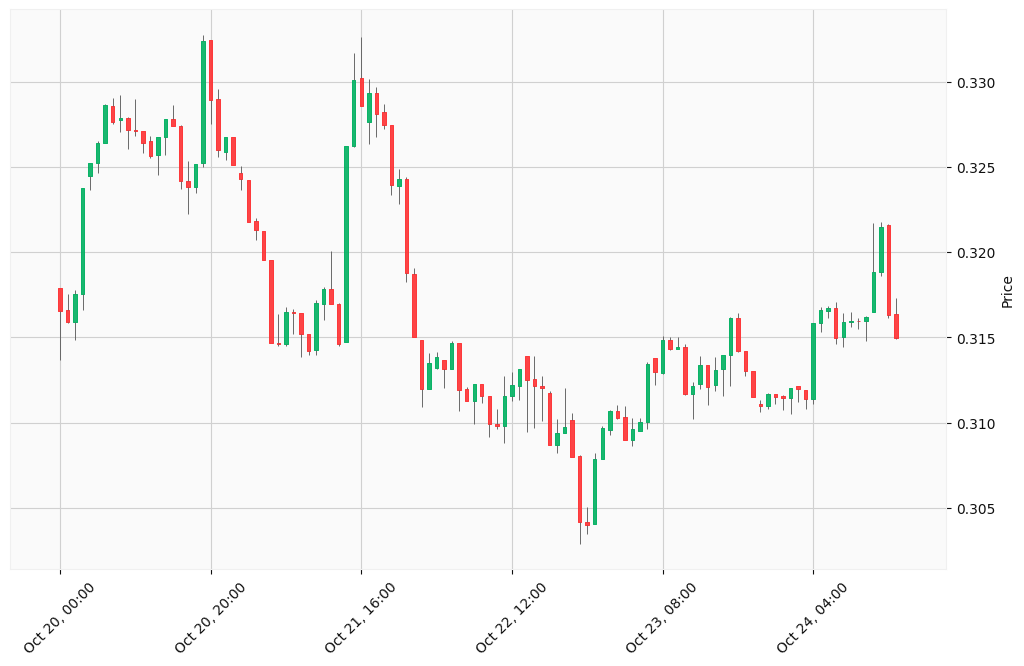

Okay, I will analyze the provided XLM-USD charts (daily for the last three months and hourly for the last five days) to generate buy and sell trading signals. I will follow the steps you outlined, incorporating technical analysis, trend analysis, news/economic factors (using search), and scenario evaluation to produce the trading signals.

Here’s how I’ll approach this:

1. **Initial Assessment (based on provided data):**
   - **Daily Chart:** I’ll calculate some basic indicators like moving averages and RSI using the daily data to get a sense of the overall trend and potential overbought/oversold conditions over the last three months.
   - **Hourly Chart:** I’ll examine the recent hourly data for more immediate trends and potential short-term trading opportunities.
2. **Augment with Search:** I’ll use the search tool to gather current news and sentiment around XLM-USD and the broader crypto market to refine the analysis.
3. **Signal Generation:** I’ll combine the technical analysis and external factors to generate buy/sell signals with confidence levels and justifications.

Okay, I’ve gathered some information. Here’s a breakdown and the trading signals:

**Summary of Findings:**

- **Market Sentiment:** Overall, the cryptocurrency market is experiencing growth this week.
- **XLM Recent Performance:** XLM’s price is around $0.31-$0.32. It has shown some recent volatility, with a mix of positive and negative sentiment.
- **Technical Indicators:** Technical analysis of XLM points to a “strong sell” signal based on moving averages, while oscillators are neutral.
- **News and Developments:**
  - XLM saw a price drop in October, but investors used this as an opportunity to accumulate the token.
  - The total value locked (TVL) on the Stellar chain has surged.
  - There’s been a large outflow of XLM from Binance, suggesting accumulation or movement to DeFi platforms.
  - The funding rate for XLM futures contracts has been negative, indicating bearish sentiment among traders.
- **Bullish factors**: Positive sentiment on social media. Derivatives data indicates improving sentiment, with funding rates turning positive and bullish positions rising.

**Calculations based on provided data**

**Daily Chart Analysis (3 Months):**

To analyze the daily chart data provided, I will calculate the 50-day and 200-day Simple Moving Averages (SMA) and the Relative Strength Index (RSI). Since I only have three months of data, the 200-day SMA will be less reliable.

1. **Simple Moving Averages (SMA):**
   - **50-day SMA:** To calculate this, I would average the closing prices over the last 50 days.
   - **200-day SMA:** Similarly, average the closing prices over the last 200 days.
2. **Relative Strength Index (RSI):**
   - **RSI:** This indicator helps identify overbought or oversold conditions. It’s typically calculated over a 14-day period.